# Introduction to Exploratory Data Analysis and Applied Statistical Techniques

Module 01

Ray J. Hoobler

# Data Visualization

## Visualizations Are Not New

[figure not shown]

1977

> “The simple graph has brought more information nto the data analyst’s mind than any other device.”  
> —John Tukey

*Exploratory Data Analysis* by John Tukey(Tukey 1977), is now considered a classic in the field of data analysis and statistics.

Four chapters are devoted to *Graphic Presentation* in my copy of *Applied General Statistics* (Croxton and Cowden 1946). (The book was first published in 1939.)

## R for Data Science (2e)

2023

*R for Data Science* is an introduction into data manipulation and visualization. The authors are proponents of the **tidyverse** and **ggplot2**. The tidyverse is a collection of R packages designed for data science. This is in contrast to *base R*.

The tidyverse provides an integrated framework that allows beginners to quickly get up to speed with data manipulation.

ggpot2 is a plotting system for R, based on the grammar of graphics. Once you become familiar with ggplot, you will see it’s presence in many publications. *A Layered Grammar of Graphics* (Wickham 2010) provides the philosophical framework for ggplot2.

## Prerequisites

Before you begin any readings, you should have R and RStudio installed on your computer.

Follow the instructions on the [Posit.co](https://posit.co/download/rstudio-desktop/) website for installing the RStudio IDE (integrated development environment).

1. Install R from the [Rstudio.com mirror of the CRAN website](https://cran.rstudio.com/).
2. Install RStudio from [Posit.co](https://posit.co/download/rstudio-desktop/).

## Getting Started

Once you have R and RStudio installed, start RStudio and type `library(tidyverse)` in the console.

```r
library(tidyverse)
```

You’ll see the following message the first time you load the package.

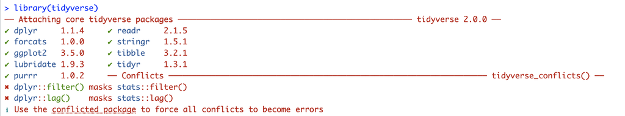

## The Palmer Penguins Dataset

The Palmer Penguins dataset (Horst et al. 2020) is a popular dataset for learning data visualization. It is bundled with the **palmerpenguins** package. The dataset was created by Allison Horst, Alison Hill, and Kristen Gorman. The dataset is available on [GitHub](https://github.com/allisonhorst/palmerpenguins).

```r
library(palmerpenguins)
```

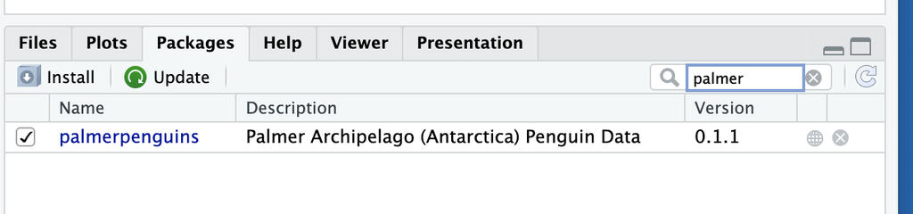

## Data Frames

Data frames will be the default data structure we use in this course. Data frames should look familiar to anyone who has used spreadsheets.

```r
penguins
```

| species | island | bill_length_mm | bill_depth_mm | flipper_length_mm | body_mass_g | sex | year |
| --- | --- | --- | --- | --- | --- | --- | --- |
| Adelie | Torgersen | 39.1 | 18.7 | 181 | 3750 | male | 2007 |
| Adelie | Torgersen | 39.5 | 17.4 | 186 | 3800 | female | 2007 |
| Adelie | Torgersen | 40.3 | 18.0 | 195 | 3250 | female | 2007 |
| Adelie | Torgersen | NA | NA | NA | NA | NA | 2007 |
| Adelie | Torgersen | 36.7 | 19.3 | 193 | 3450 | female | 2007 |
| Adelie | Torgersen | 39.3 | 20.6 | 190 | 3650 | male | 2007 |
| Adelie | Torgersen | 38.9 | 17.8 | 181 | 3625 | female | 2007 |
| Adelie | Torgersen | 39.2 | 19.6 | 195 | 4675 | male | 2007 |
| Adelie | Torgersen | 34.1 | 18.1 | 193 | 3475 | NA | 2007 |
| Adelie | Torgersen | 42.0 | 20.2 | 190 | 4250 | NA | 2007 |

[output cut: 334 more lines]

Variables are in columns and observations are in rows.

## “Ultimate goal” for Chapter 1 in *R for Data Science*

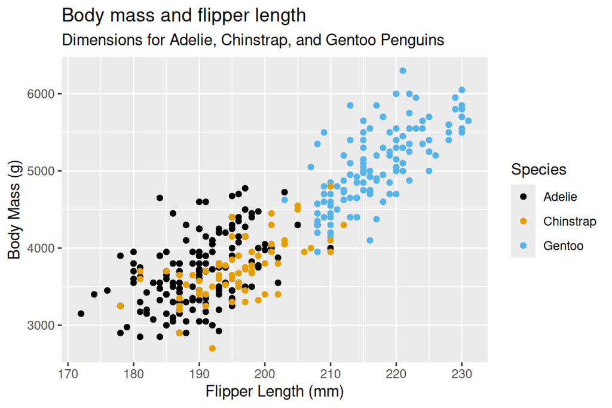

```r
library(ggthemes)

ggplot(
  data = penguins,
  mapping = aes(x = flipper_length_mm, y = body_mass_g)
  ) +
  geom_point(mapping = aes(color = species)) +
  labs(
    title = "Body mass and flipper length",
    subtitle = "Dimensions for Adelie, Chinstrap, and Gentoo Penguins",
    x = "Flipper Length (mm)",
    y = "Body Mass (g)",
    color = "Species"
  ) +
  scale_color_colorblind()
```

## Visualizations with ggplot: Step 1

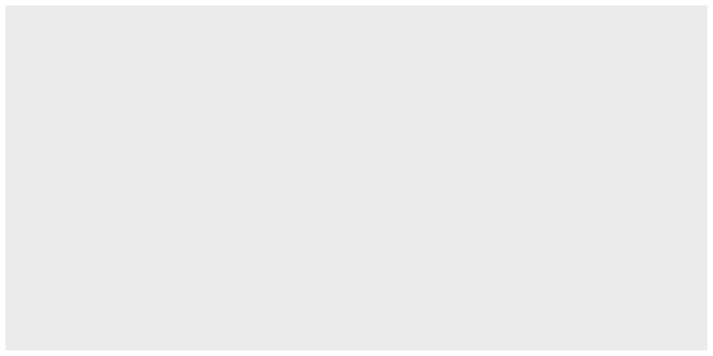

```r
ggplot(data = penguins)
```

## Visualilzations with ggplot: Step 2

```r
ggplot(
  data = penguins,
  mapping = aes(x = flipper_length_mm, y = body_mass_g)
)
```

[figure not shown]

## Visualizations with ggplot: Step 3

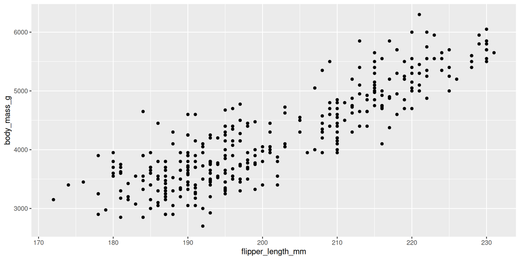

```r
ggplot(
  data = penguins,
  mapping = aes(x = flipper_length_mm, y = body_mass_g)
) +
  geom_point()
```

**Warning**

Warning: [38;5;232mRemoved 2 rows containing missing values or values outside the scale range (`geom_point()`).[39m

## Visualizations with ggplot: Step 4

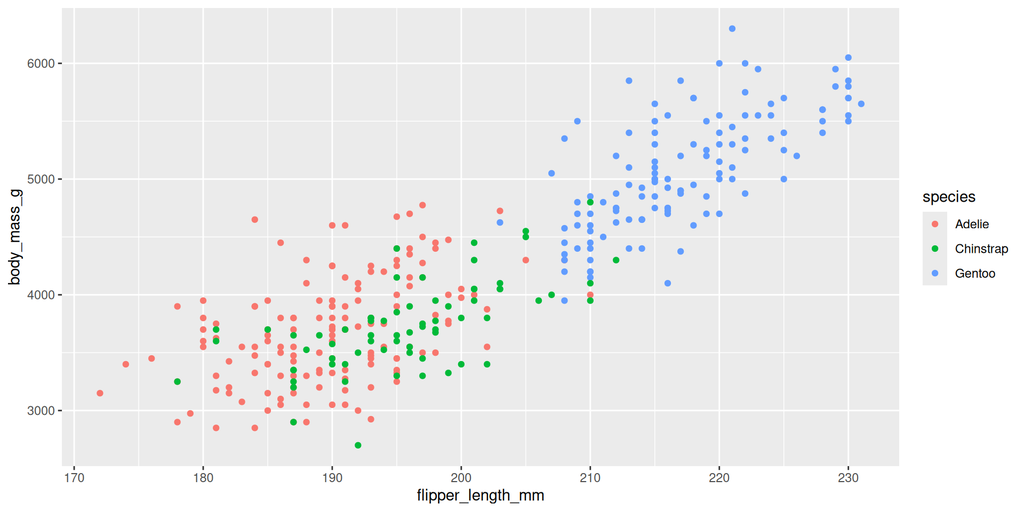

```r
ggplot(
  data = penguins,
  mapping = aes(x = flipper_length_mm, y = body_mass_g, color = species)
) +
  geom_point()
```

## Visualizations with ggplot: Step 5

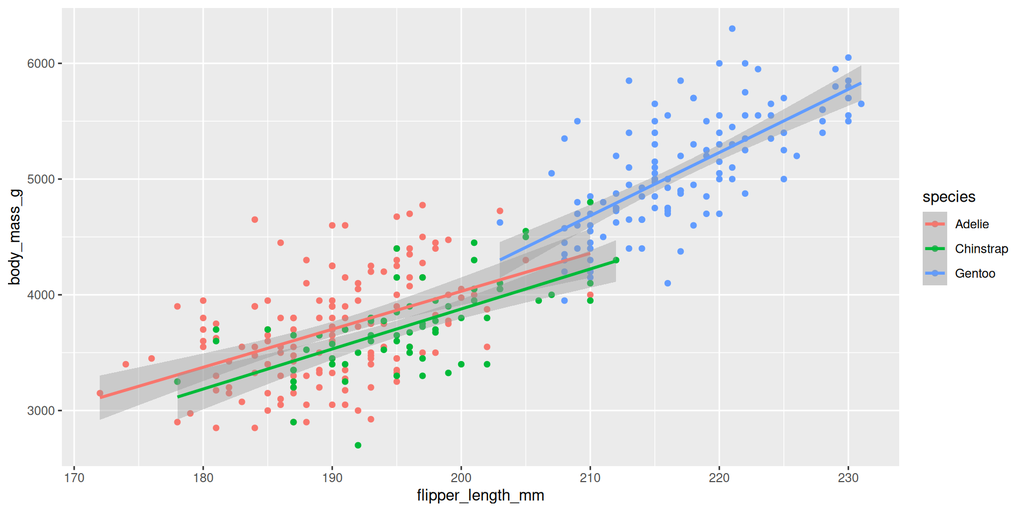

```r
ggplot(
  data = penguins,
  mapping = aes(x = flipper_length_mm, y = body_mass_g, color = species)
) +
  geom_point() +
  geom_smooth(method = "lm")
```

**Important**

When aesthetic mappings are defined in the `ggplot()` function, they are inherited by all layers.

The aesthetic “color” is being applied to both the `geom_point()` and `geom_smooth()` layers.

## Visualizations with ggplot: Step 6

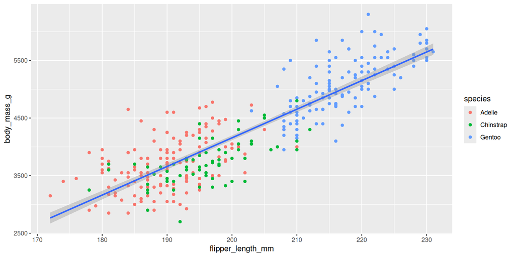

```r
ggplot(
  data = penguins,
  mapping = aes(x = flipper_length_mm, y = body_mass_g)
) +
  geom_point(mapping = aes(color = species)) +
  geom_smooth(method = "lm")
```

## Visualizations with ggplot: Step 7

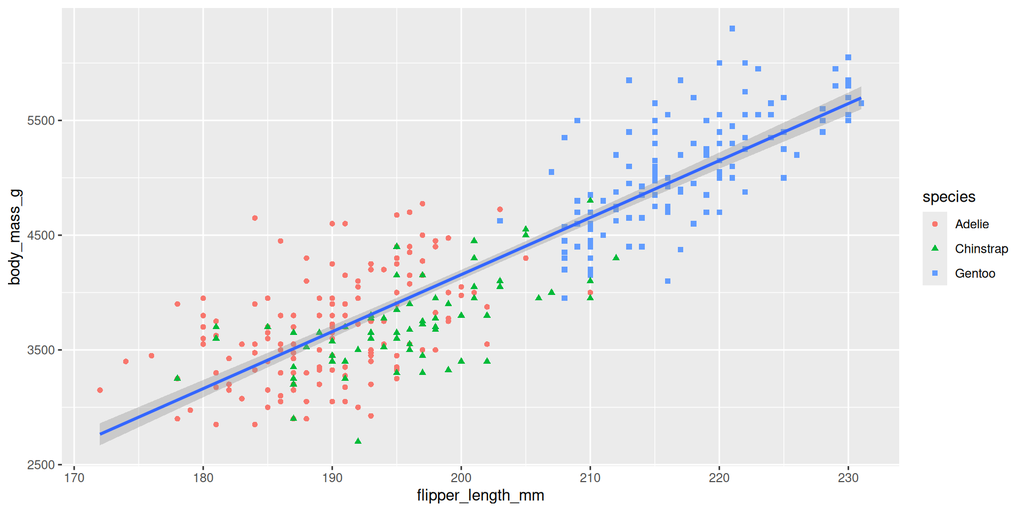

```r
ggplot(
  data = penguins,
  mapping = aes(x = flipper_length_mm, y = body_mass_g)
) +
  geom_point(mapping = aes(color = species, shape = species)) +
  geom_smooth(method = "lm")
```

## Visualizations with ggplot: Step 8

````markdown
```{r}
ggplot(
  data = penguins,
  mapping = aes(x = flipper_length_mm, y = body_mass_g)
) +
  geom_point(mapping = aes(color = species, shape = species)) +
  geom_smooth(method = "lm") +
  labs(
    title = "Body mass and flipper length",
    subtitle = "Dimensions for Adelie, Chinstrap, and Gentoo Penguins",
    x = "Flipper Length (mm)",
    y = "Body Mass (g)",
    color = "Species",
    shape = "Species"
  ) +
  scale_color_colorblind()
```
````

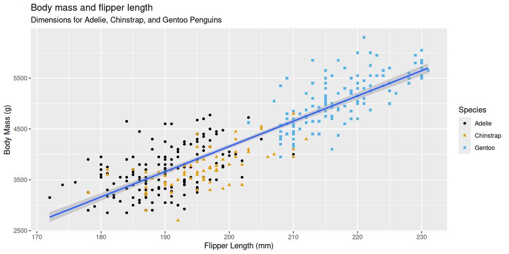

```r
ggplot(
  data = penguins,
  mapping = aes(x = flipper_length_mm, y = body_mass_g)
) +
  geom_point(mapping = aes(color = species, shape = species)) +
  geom_smooth(method = "lm") +
  labs(
    title = "Body mass and flipper length",
    subtitle = "Dimensions for Adelie, Chinstrap, and Gentoo Penguins",
    x = "Flipper Length (mm)",
    y = "Body Mass (g)",
    color = "Species",
    shape = "Species"
  ) +
  scale_color_colorblind()
```

## Module 1 Assignment 1

Create a new Quarto html document and answer questions 1 through 10 in the *R for Data Science* section [1.2.5 Exercises](https://r4ds.hadley.nz/data-visualize#exercises).

# Exploratory Data Analysis

## NIST/SEMATECH e-Handbook of Statistical Methods

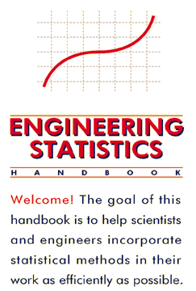

The NIST/SEMATECH e-Handbook of Statistical Methods is a collaborative project involving the National Institute of Standards and Technology (NIST) and SEMATECH.

NIST is a non-regulatory federal agency within the U.S. Department of Commerce. The main role of NIST is to promote U.S. innovation and industrial competitiveness by advancing measurement science, standards, and technology.

SEMATECH was a research consortium comprised of semiconductor manufacturers and suppliers.

## What is EDA According to NIST/SEMATECH?

[1.1.1](https://www.itl.nist.gov/div898/handbook/eda/section1/eda11.htm)

> Exploratory Data Analysis (EDA) is an approach/philosophy for data analysis that employs a variety of techniques (mostly graphical) to
> - maximize insight into a data set;
> - uncover underlying structure;
> - extract important variables;
> - detect outliers and anomalies;
> - test underlying assumptions;
> - develop parsimonious models; and
> - determine optimal factor settings.

## EDA Techniques Encouraged by NIST/SEMATECH

[1.1.1](https://www.itl.nist.gov/div898/handbook/eda/section1/eda11.htm)

> The particular graphical techniques emplooyed in EDA are often quite simple, consisting of various techniques of:
> - Plotting the raw data. (Scatter plots, histograms, probability plots, etc.)
> - Plotting simple statistics. (Mean plots, standard deviation plots, box plots, etc.)
> - Positioning such plots to maximize our natural pattern-recognition abilities, such as using multiple plots per page. (Subplots, faceting, etc.)

## EDA Goals According to NIST/SEMATECH

[1.1.4](https://www.itl.nist.gov/div898/handbook/eda/section1/eda14.htm)

> The primary goal of EDA is to maximize the analyst’s insight into a data set and into the underlying structure of a data set, while providing all of the specific items that an analyst would want to extract from a data set, such as:
> - a good-fitting, parsimonious model;
> - a list of outliers;
> - a sense of robustness of conclusions;
> - estimates for model parameters;
> - uncertainties for those estimates;
> - a ranked list of important factors;
> - conclusions as to whether individual factors are significant;
> - optimal settings.

## EDA Assumptions According to NIST/SEMATECH

[1.2.1](https://www.itl.nist.gov/div898/handbook/eda/section2/eda21.htm)

> Data from a process or experiment “behaves like”
> - a random drawing;
> - from a fixed distribution;
> - with the distribution having a fixed location; and
> - with the distribution having a fixed variation.

# Visualizing Distributions

## Distribution of a Categorical Variable (1/2)

What are categorical variables in the Palmer Penguins dataset?  
What do we calcluate with distributions?

```r
penguins
```

| species | island | bill_length_mm | bill_depth_mm | flipper_length_mm | body_mass_g | sex | year |
| --- | --- | --- | --- | --- | --- | --- | --- |
| Adelie | Torgersen | 39.1 | 18.7 | 181 | 3750 | male | 2007 |
| Adelie | Torgersen | 39.5 | 17.4 | 186 | 3800 | female | 2007 |
| Adelie | Torgersen | 40.3 | 18.0 | 195 | 3250 | female | 2007 |
| Adelie | Torgersen | NA | NA | NA | NA | NA | 2007 |
| Adelie | Torgersen | 36.7 | 19.3 | 193 | 3450 | female | 2007 |
| Adelie | Torgersen | 39.3 | 20.6 | 190 | 3650 | male | 2007 |
| Adelie | Torgersen | 38.9 | 17.8 | 181 | 3625 | female | 2007 |
| Adelie | Torgersen | 39.2 | 19.6 | 195 | 4675 | male | 2007 |
| Adelie | Torgersen | 34.1 | 18.1 | 193 | 3475 | NA | 2007 |
| Adelie | Torgersen | 42.0 | 20.2 | 190 | 4250 | NA | 2007 |

[output cut: 334 more lines]

## Distribution of a Categorical Variable (2/2)

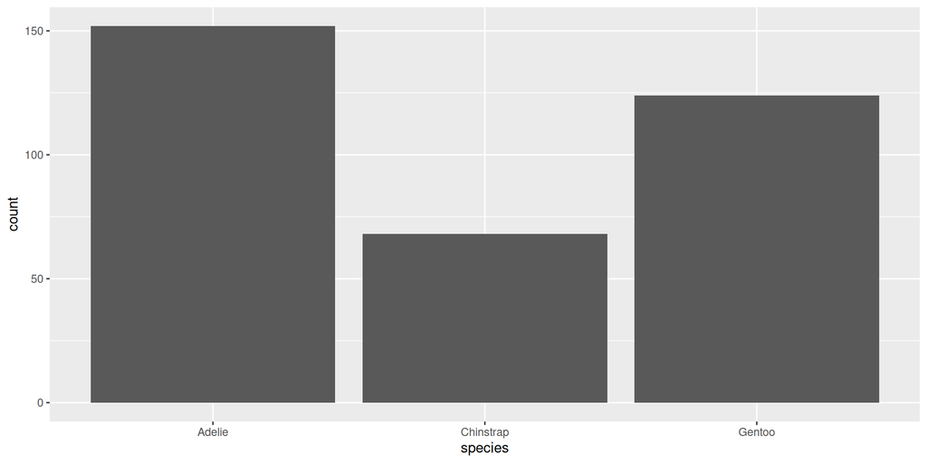

```r
ggplot(penguins, aes(x = species)) +
  geom_bar()
```

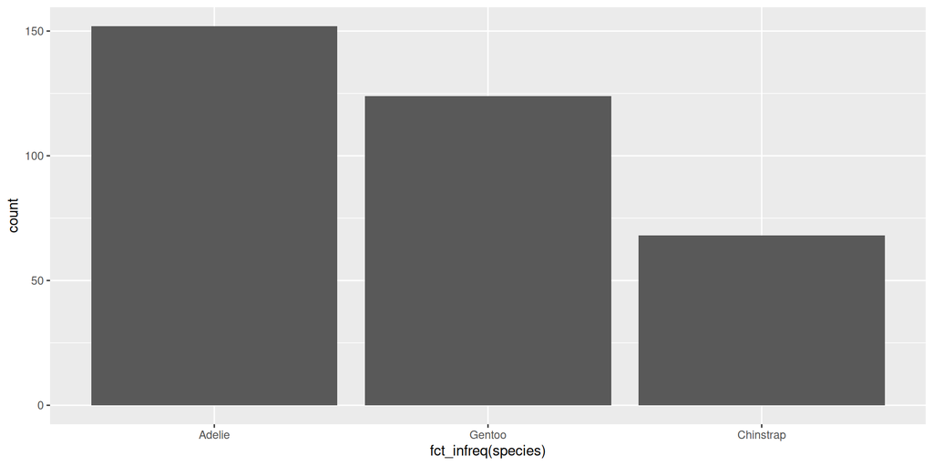

```r
ggplot(penguins, aes(x = fct_infreq(species))) +
  geom_bar()
```

## Distribution of a Numerical Variable (1/2)

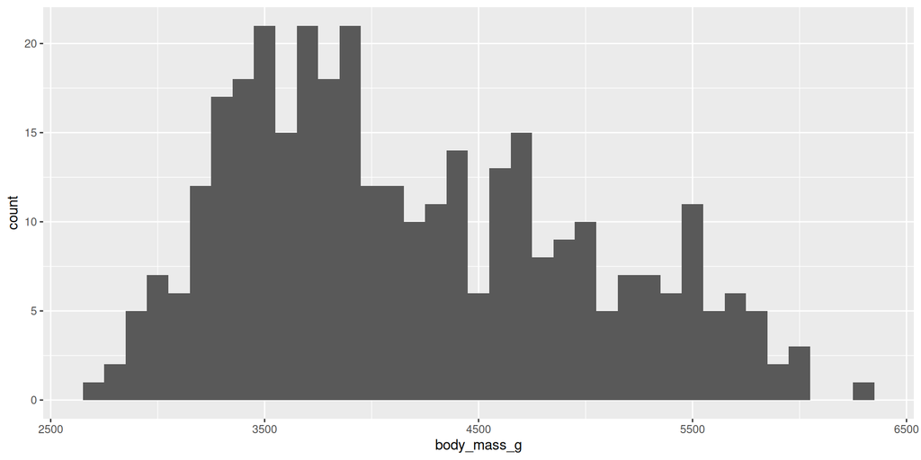

```r
ggplot(penguins, aes(x = body_mass_g)) +
  geom_histogram(binwidth = 100, na.rm = TRUE)
```

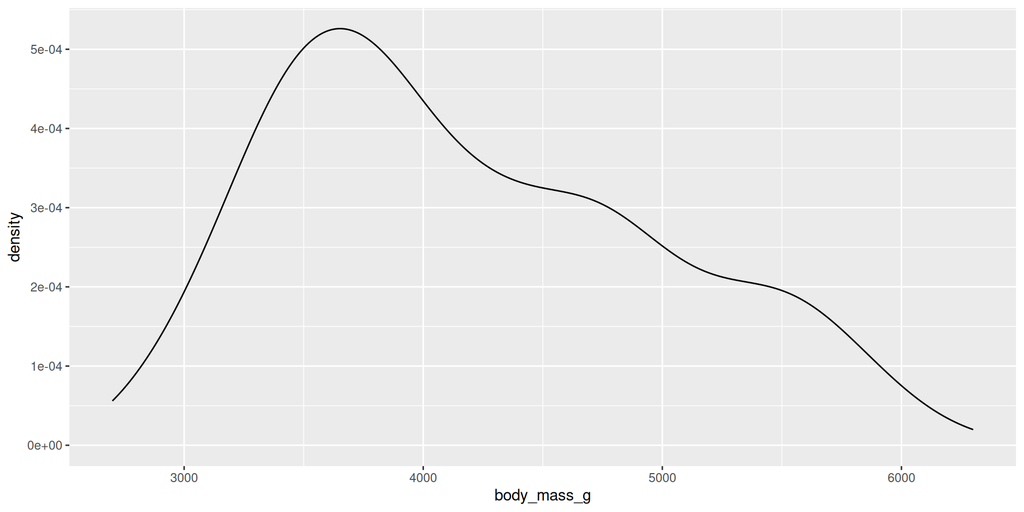

```r
ggplot(penguins, aes(x = body_mass_g)) +
  geom_density(na.rm = TRUE)
```

## Distribution of a Numerical Variable (2/2)

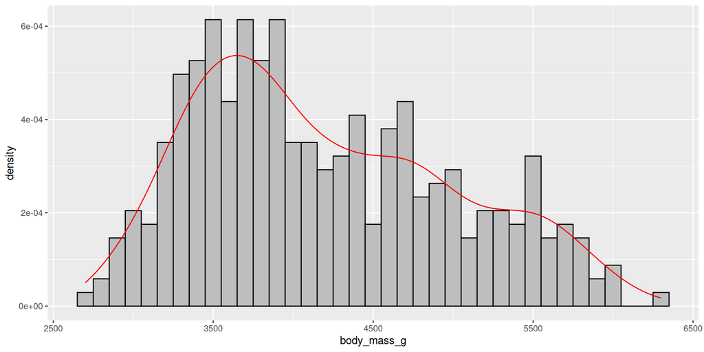

```r
ggplot(penguins, aes(x = body_mass_g, y=after_stat(density))) +
  geom_histogram(binwidth = 100, na.rm = TRUE, fill = "grey", color="black") +
  geom_density(kernel = "gaussian", bw = 200, na.rm = TRUE, color = "red")
```

# Visualizing Relationships

## A Numerical and a Categorical Cariable

What are the key components of a **boxplot**?

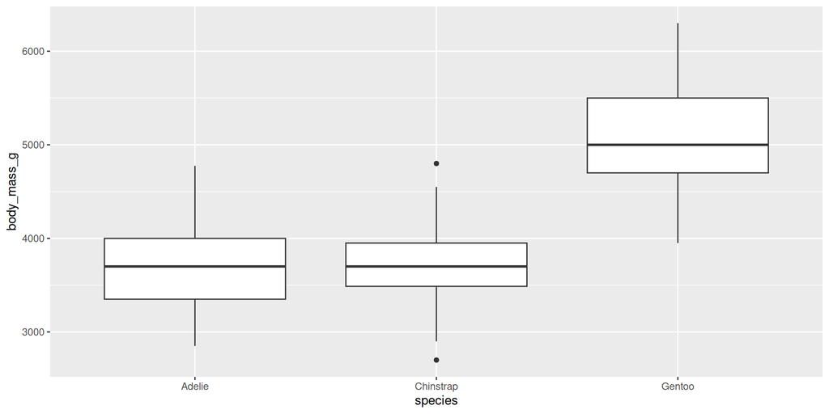

```r
ggplot(penguins, aes(x = species, y = body_mass_g)) +
  geom_boxplot(na.rm = TRUE)
```

What relationships are visible in a **density** plot?

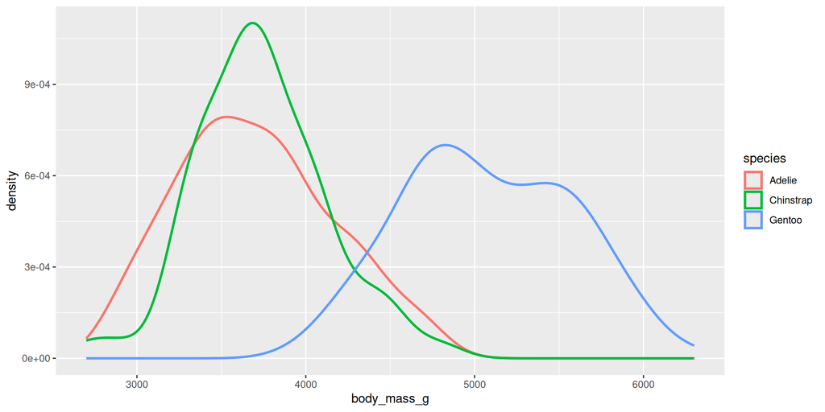

```r
ggplot(penguins, aes(x = body_mass_g, color = species)) +
  geom_density(linewidth = 1, na.rm = TRUE)
```

## Two Categorical Variables

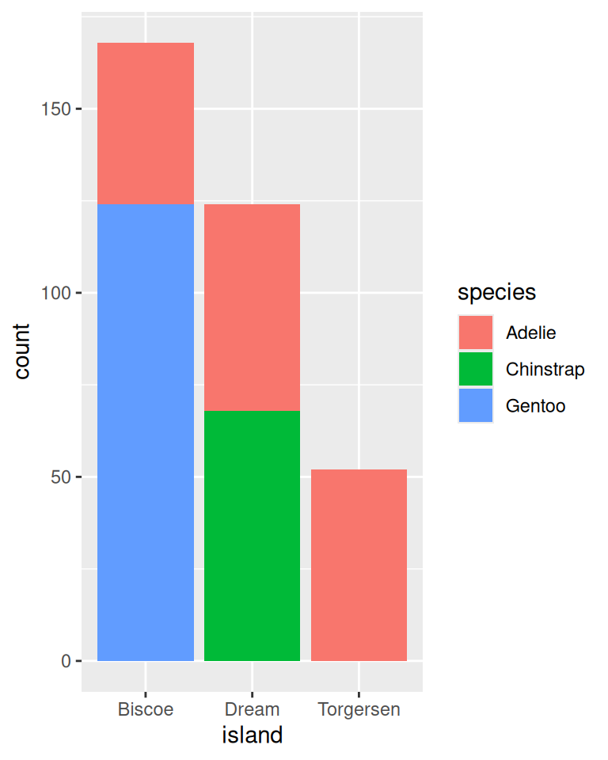

```r
ggplot(penguins,
       aes(x = island, fill = species)) +
  geom_bar()
```

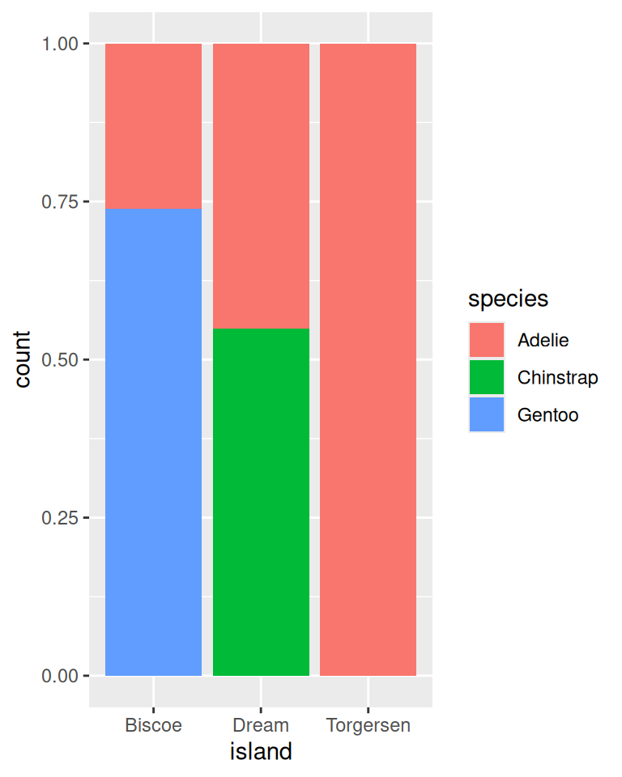

```r
ggplot(penguins,
       aes(x = island, fill = species)) +
  geom_bar(position = "fill")
```

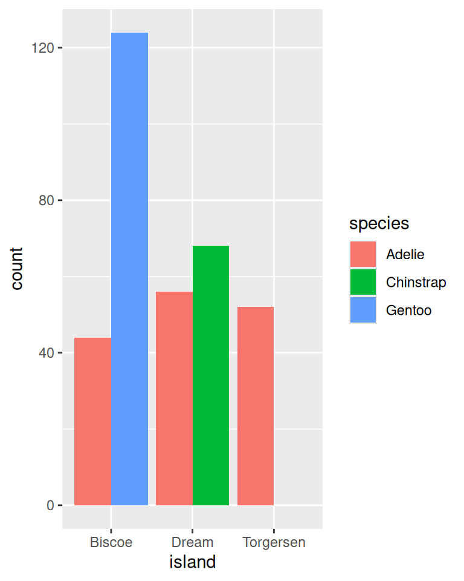

```r
ggplot(penguins,
       aes(x = island, fill = species)) +
  geom_bar(position = position_dodge(preserve = "single"))
```

## Two Numerical Variables

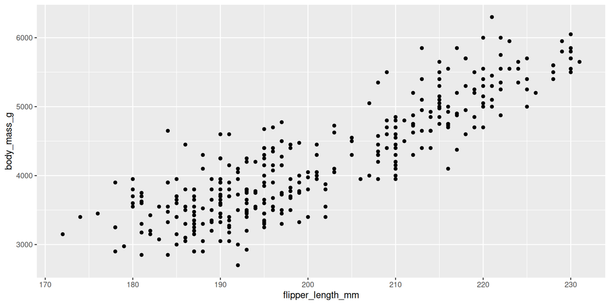

```r
ggplot(penguins, aes(x = flipper_length_mm, y = body_mass_g)) +
  geom_point()
```

## Three or more variables

### Mapping variables to aesthetics

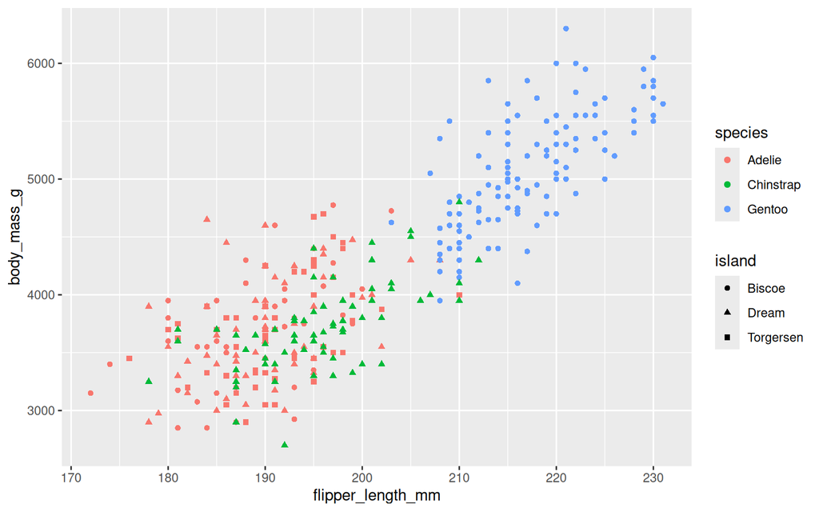

```r
ggplot(penguins, aes(x = flipper_length_mm,
                     y = body_mass_g,
                     color = species, shape = island)) +
  geom_point()
```

### Faceting

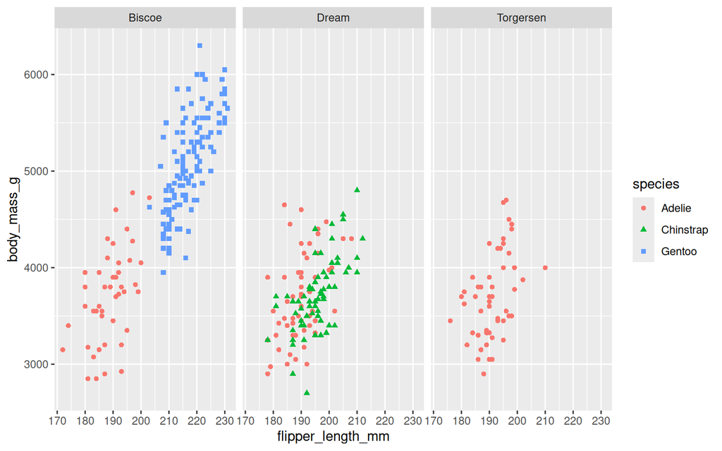

```r
ggplot(penguins, aes(x = flipper_length_mm,
                     y = body_mass_g,
                     color = species, shape = species)) +
  geom_point() +
  facet_wrap(~island)
```

## Module 1 Assignment 2

Create a new Quarto html document and answer questions 1, 2, and 6 in the *R for Data Science* section [1.5.5 Exercises](https://r4ds.hadley.nz/data-visualize#exercises-2).

# End of Module 1

## References

Croxton, Frederick E., and Dudley J. Cowden. 1946. *Applied General Statistics*. Prentice-Hall.

Horst, Allison Marie, Alison Presmanes Hill, and Kristen B Gorman. 2020. *Palmerpenguins: Palmer Archipelago (Antarctica) Penguin Data*. https://doi.org/10.5281/zenodo.3960218.

Tukey, John Wilder. 1977. *Exploratory Data Analysis*. Addison-Wesley Series in Behavioral Science. Addison-Wesley Pub. Co.

Wickham, Hadley. 2010. “A Layered Grammar of Graphics.” *Journal of Computational and Graphical Statistics* 19 (1): 3–28. https://doi.org/10.1198/jcgs.2009.07098.